# homework1_xw2598

Xinyao WU

2018/9/18

# *problem 1*

## code chunk 1

Generate a data_frame included:

10 uniform random variables with values b/w 0 and 5

A logical vector indicating whether elements of random_sample are greater than 2

A (length-10) character vector

A (length-10) factor vector

```r
library(tidyverse)
dt_frame = tibble(
  random_sample = runif(10, min = 0, max = 5) ,
  logical_vector = random_sample > 2 ,
  ch_vector = c("a", "b", "c", "d", "e", "f", "g", "h", "i", "j") ,
  factor_vector = as.factor(ch_vector)
)
dt_frame = as.data.frame(dt_frame)

# view top lines of dt_frame
head(dt_frame)
```

```
##   random_sample logical_vector ch_vector factor_vector
## 1     1.2992547          FALSE         a             a
## 2     4.4664183           TRUE         b             b
## 3     0.4111899          FALSE         c             c
## 4     1.6761864          FALSE         d             d
## 5     1.3927948          FALSE         e             e
## 6     1.4286727          FALSE         f             f
```

## The mean of each variable in the dataframe

The mean of **random sample** is 1.9846236

The mean of the **logical vector** is 0.4

The mean of the **character vector** is NA

The mean of the **list of factor vector** is NA

**Explanation:**When applying the function of mean(),the random sample and logical vector worked while character vector and factor vector didn`t work. That is because according to the useage of mean(), the elements of the vector should be umeric/logical vectors and date, date-time and time interval objects.

## code chunk 2

```r
#change character to numeric
chr_to_num = as.numeric(dt_frame$ch_vector)
#change character to factor
chr_to_factor = as.factor(dt_frame$ch_vector)
#change factor to character
factor_to_chr = as.character(dt_frame$factor_vector)
#change factor to numeric
factor_to_num = as.numeric(dt_frame$factor_vector)
#change logical to numeric
logic_to_num = as.numeric(dt_frame$logical_vector)
```

**Explanation**The warning (not shown above) means the variables cannot be converted from character to numberic. Except that, some other kinds of conversions(exp:factor to numberic to character,logic to numberic, character to factor ) can be realized successfully.

# *problem 2*

## code chunk 3

Create a data_frame included:

Respectivgely generate x,y: a random sample of size 1000 from a standard Normal distribution.

A logical vector indicating whether the x + y > 0.

A numeric vector created by coercing the above logical vector.

A factor vector created by coercing the above logical vector.

```r
dt_frame2 = tibble(
  x = rnorm(1000, mean = 0, sd = 1) ,
  y = rnorm(1000, mean = 0, sd = 1) ,
  vc_logic = x + y > 0 ,
  vc_num = as.numeric(vc_logic) ,
  vc_factor = as.factor(vc_logic)
)
dt_frame2 = as.data.frame(dt_frame2)

head(dt_frame2)
```

```
##            x          y vc_logic vc_num vc_factor
## 1 -1.0873155 -0.6695321    FALSE      0     FALSE
## 2 -0.4935479 -0.7082801    FALSE      0     FALSE
## 3 -1.2118432 -0.5222860    FALSE      0     FALSE
## 4  1.3958161  0.4529587     TRUE      1      TRUE
## 5 -0.2866515  0.9001009     TRUE      1      TRUE
## 6 -2.5108542 -0.7382981    FALSE      0     FALSE
```

The size of the dataset is 1000 rows* 5 columns .

The mean of x is -0.0209571 and the median of x is -0.0351698 .

The proportion of cases for which the logical vector is TRUE is 0.465.

## scatterplot

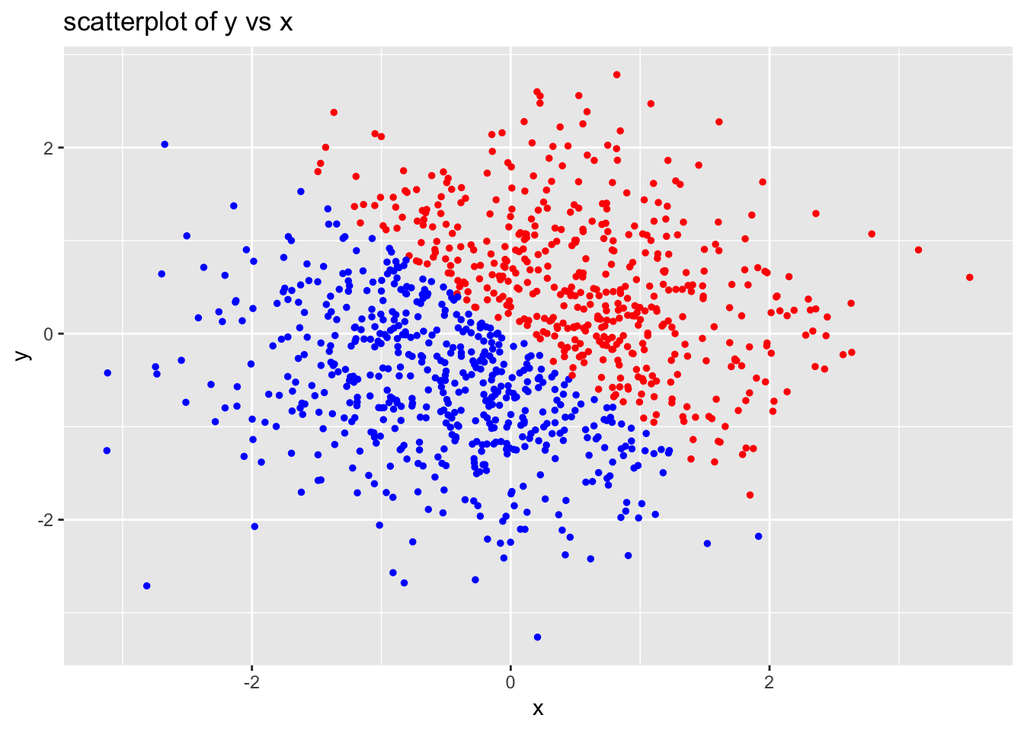

```r
#Create scarrerplot of y vs x and the point colored by logical variable
ggplot(dt_frame2, mapping = aes(x, y))+
  geom_point(data = dt_frame2, aes(x, y),
             col = ifelse(dt_frame2$vc_logic, "red", "blue"),
             size =1 ) +
  labs(title = "scatterplot of y vs x ")
```

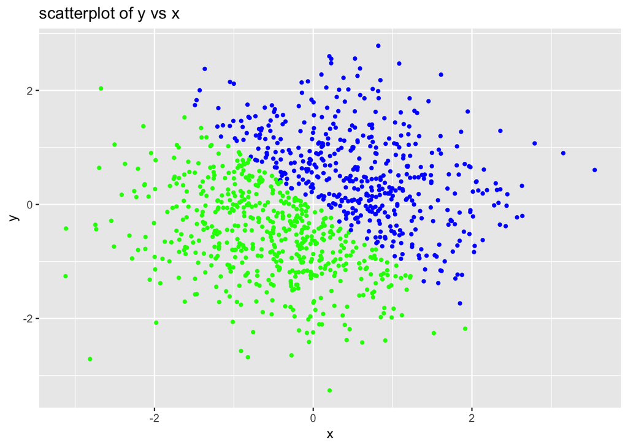

```r
ggsave("scatterplot_of_x_vs_y_colored_logic.pdf")
#Create scarrerplot of y vs x and the point colored by numberic variable
ggplot(dt_frame2, mapping = aes(x, y))+
  geom_point(data = dt_frame2, aes(x, y),
             col = ifelse(dt_frame2$vc_num, "blue", "green"),
             size =1 ) +
  labs(title = "scatterplot of y vs x ")
```

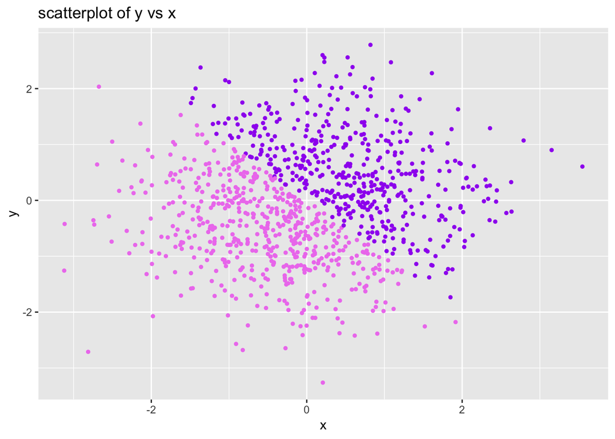

```r
#Create scarrerplot of y vs x and the point colored by factor variable
ggplot(dt_frame2, mapping = aes(x, y))+
  geom_point(data = dt_frame2, aes(x, y),
             col = ifelse(dt_frame2$vc_factor == "TRUE", "purple", "violet"),
             size =1 ) +
  labs(title = "scatterplot of y vs x ")
```